# Coral Reef Health and Organismal Occurrence Analysis Project

Jonah Kotzen, Elisabeth Laviolette, Lauren Geary, Elizabeth Breitmeyer & Katie Miller

2023-12-06

## Introduction

The “Coral Reef Health and Organismal Occurrence Analysis Project” is a comprehensive study undertaken to understand the impact of environmental conditions on coral reef ecosystems and the distribution of various marine species. Led by Jonah Kotzen, Elisabeth Laviolette, Lauren Geary, Elizabeth Breitmeyer, and Katie Miller, this project focuses on analyzing coral reef health data and fish occurrence data from 1980 to 2023, with a particular emphasis on the Great Barrier Reef. The study aims to shed light on the ecological dynamics within these complex marine ecosystems, providing insights that are crucial for effective conservation and management strategies.

## Objectives

- Primary Objective: To analyze the relationship between environmental severity, as indicated by coral bleaching events, and the occurrence of key marine species in the Great Barrier Reef.
- Secondary Objective: To understand the spatial distribution of these impacts across different zones within the reef and over various time periods.

## Methodology

- Coral Reef Health Data: Sourced from comprehensive databases, this data includes information on coral bleaching events, severity codes, and geographical locations within the reef.
- Fish Occurrence Data: Accessed using the rgbif package, this data represents observations of various marine species within Australian waters, focusing on the Great Barrier Reef. Data Processing
- The data was filtered, processed, and categorized into different time ranges (1980-1990, 1991-2000, 2001-2010).
- Observation counts for each species were tallied, and the data was mapped to visualize the distribution of severity codes and species occurrence.

### Data Retrieval and Processing

#### Using `rgbif` for Fish Occurrence Data

```r
data_list <- readRDS(file = "data_list.rds")
```

```r
# Directly combine all the data frames into one tibble without filtering NULL values
combined_data <- bind_rows(lapply(data_list, `[[`, "data"))

# Count the number of observations for each species
species_counts <- combined_data %>%
  count(species)

# Calculate the minimum and maximum years in combined_data
year_range_check_CD <- combined_data %>%
  group_by(species) %>%
  summarise(
    min_year = min(year, na.rm = TRUE),
    max_year = max(year, na.rm = TRUE)
  )

# View the resulting tibble
print(year_range_check_CD)
```

```
## # A tibble: 6 × 3
##   species               min_year max_year
##   <chr>                    <int>    <int>
## 1 Abudefduf vaigiensis      2000     2023
## 2 Cephalopholis miniata     2000     2023
## 3 Chaetodon rainfordi       2000     2023
## 4 Chlorurus sordidus        2000     2023
## 5 Triaenodon obesus         2009     2023
## 6 Tridacna gigas            2000     2023
```

[output not shown]

[output not shown]

```r
filtered_data <- bleachingdata %>%
  select(LATITUDE, LONGITUDE, YEAR, SEVERITY_CODE, LOCATION) %>%
  filter(complete.cases(.))
```

```r
# Define the latitude and longitude boundaries of the Great Barrier Reef
lat_min <- -24   # Southernmost latitude
lat_max <- -11   # Northernmost latitude
long_min <- 142  # Westernmost longitude
long_max <- 154  # Easternmost longitude

# Add the within_reef column
filtered_data <- filtered_data %>%
  mutate(within_reef = LATITUDE >= lat_min & LATITUDE <= lat_max &
                        LONGITUDE >= long_min & LONGITUDE <= long_max)


# Group by the within_reef column and count the number of TRUE and FALSE values
reef_count <- filtered_data %>%
  group_by(within_reef) %>%
  summarise(count = n())

# The reef_count tibble now contains the count of TRUE and FALSE values in the within_reef column.

reef_data <- filtered_data %>%
  filter(within_reef == TRUE)
```

```r
# Determine new latitude boundaries for each zone based on quantiles
zone_boundary_1 <- quantile(reef_data$LATITUDE, probs = 1/3)
zone_boundary_2 <- quantile(reef_data$LATITUDE, probs = 2/3)

# Re-assign the reef_zone column
reef_data <- reef_data %>%
  mutate(reef_zone = case_when(
    LATITUDE <= zone_boundary_1 ~ "A",
    LATITUDE > zone_boundary_1 & LATITUDE <= zone_boundary_2 ~ "B",
    TRUE ~ "C"
  ))

# Check the new distribution
new_zone_counts <- reef_data %>%
  count(reef_zone)
```

```r
# Create a leaflet map and add tiles
reef_map <- leaflet() %>%
  addTiles() %>%  # This adds the default OpenStreetMap tiles
  setView(lng = mean(c(142, 154)), lat = mean(c(-24, -10)), zoom = 6)

# Add points to the map
reef_map <- reef_map %>%
  addCircleMarkers(data = reef_data,
                   ~LONGITUDE,
                   ~LATITUDE,
                   color = ~case_when(reef_zone == "A" ~ "green",
                                      reef_zone == "B" ~ "orange",
                                      reef_zone == "C" ~ "red"),
                   popup = ~paste("Zone:", reef_zone))

# Print the map
reef_map
```

[interactive chart not shown]

```r
library(leaflet)

# Splitting the data into the new time ranges
data_1980_1990 <- reef_data[reef_data$YEAR >= 1980 & reef_data$YEAR <= 1990, ]
data_1991_2000 <- reef_data[reef_data$YEAR >= 1991 & reef_data$YEAR <= 2000, ]
data_2001_2010 <- reef_data[reef_data$YEAR >= 2001 & reef_data$YEAR <= 2010, ]

# Function to create a map for a given dataset
create_map <- function(data, title) {
  if (nrow(data) > 0) {
    leaflet(data) %>%
      addTiles() %>%
      setView(lng = mean(c(142, 154)), lat = mean(c(-24, -10)), zoom = 6) %>%
      addCircleMarkers(~LONGITUDE, ~LATITUDE,
                       color = ~case_when(
                         SEVERITY_CODE >= 3 ~ "red",     # Most severe
                         SEVERITY_CODE >= 2 ~ "orange",  # Moderately severe
                         TRUE ~ "green"                  # Least severe
                       ),
                       popup = ~paste("Severity Code:", SEVERITY_CODE)) %>%
      addTiles() %>%
      addMarkers(lng = mean(c(142, 154)), lat = mean(c(-24, -10)), popup = title)
  } else {
    print(paste("No data available for", title))
  }
}

# Creating and printing the maps
map_1980_1990 <- create_map(data_1980_1990, "1980-1990 Severity Codes")
map_1991_2000 <- create_map(data_1991_2000, "1991-2000 Severity Codes")
map_2001_2010 <- create_map(data_2001_2010, "2001-2010 Severity Codes")
```

# Maps of Zones A, B, and C based on Severity (Green = Least Severe and Red = Most Severe)

## Severity (1980-1990)

```r
map_1980_1990
```

[interactive chart not shown]

## Severity (1991-2000)

```r
map_1991_2000
```

[interactive chart not shown]

## Severity (2001-2010)

```r
map_2001_2010
```

[interactive chart not shown]

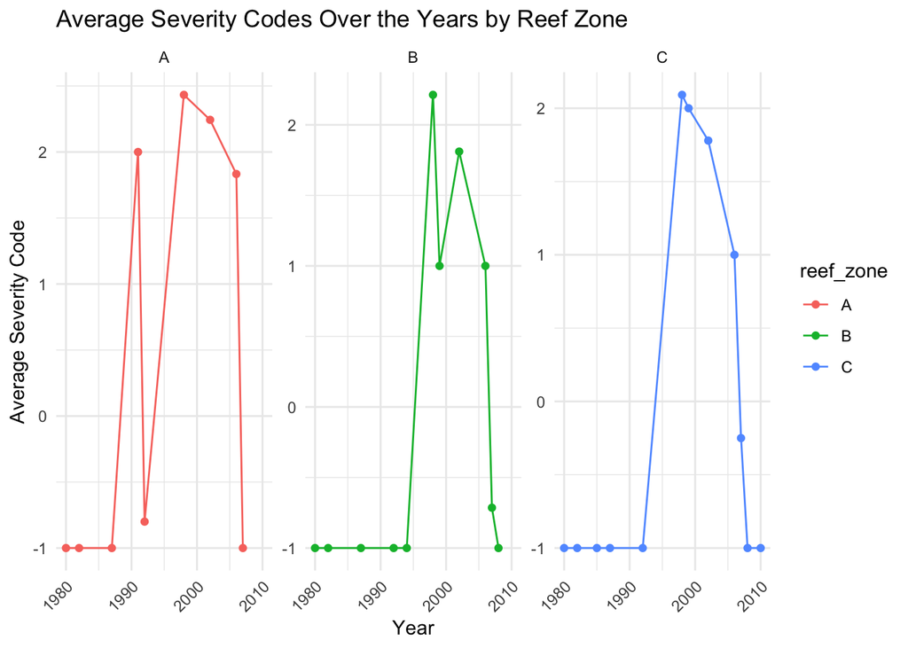

```r
library(dplyr)
library(ggplot2)

# Calculate the average SEVERITY_CODE values for each year and each reef_zone
severity_code_by_year_zone <- reef_data %>%
  group_by(YEAR, reef_zone) %>%
  summarise(
    avg_severity = mean(SEVERITY_CODE, na.rm = TRUE),
    .groups = "drop"
  )

# Plotting the average severity codes for each year, separated by reef_zone
ggplot(severity_code_by_year_zone, aes(x = YEAR, y = avg_severity, group = reef_zone, color = reef_zone)) +
  geom_line() +  # Add line to connect the dots
  geom_point() +  # Add points for each data point
  facet_wrap(~ reef_zone, scales = "free_y") +  # Separate graph for each reef_zone
  theme_minimal() +
  labs(title = "Average Severity Codes Over the Years by Reef Zone",
       x = "Year",
       y = "Average Severity Code") +
  theme(axis.text.x = element_text(angle = 45, hjust = 1))  # Rotate x-axis labels for better readability
```

```r
# Assuming zone_boundary_1 and zone_boundary_2 are already defined
# and combined_data has decimalLatitude and decimalLongitude columns

# Add the reef_zone column to combined_data
combined_data <- combined_data %>%
  mutate(reef_zone = case_when(
    decimalLatitude <= zone_boundary_1 ~ "A",
    decimalLatitude > zone_boundary_1 & decimalLatitude <= zone_boundary_2 ~ "B",
    decimalLatitude > zone_boundary_2 ~ "C"
  ))

# Now, combined_data contains the new column reef_zone with values A, B, or C

combined_data <- combined_data %>%
  select(species, decimalLatitude, decimalLongitude, year, reef_zone) %>%
  filter(complete.cases(.))
```

```r
# Count the number of unique species in each reef zone
species_observations_per_zone_year <- combined_data %>%
  filter(!is.na(reef_zone)) %>%
  group_by(reef_zone, species, year) %>%
  summarise(observation_count = n(), .groups = "drop")
```

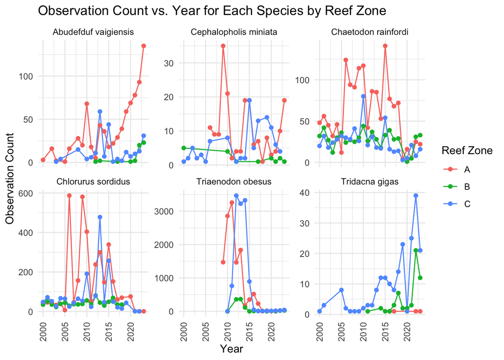

```r
# Plot observation_count vs. year for each species, facetted by species
ggplot(species_observations_per_zone_year, aes(x = year, y = observation_count, group = reef_zone, color = reef_zone)) +
  geom_line() +
  geom_point() +  # Add points to the lines
  facet_wrap(~ species, scales = "free_y") +  # Facet by species, with free y scales for each plot
  theme_minimal() +
  labs(title = "Observation Count vs. Year for Each Species by Reef Zone",
       x = "Year",
       y = "Observation Count",
       color = "Reef Zone") +
  theme(axis.text.x = element_text(angle = 90, vjust = 0.5, hjust=1))  # Rotate x-axis labels for better readability
```

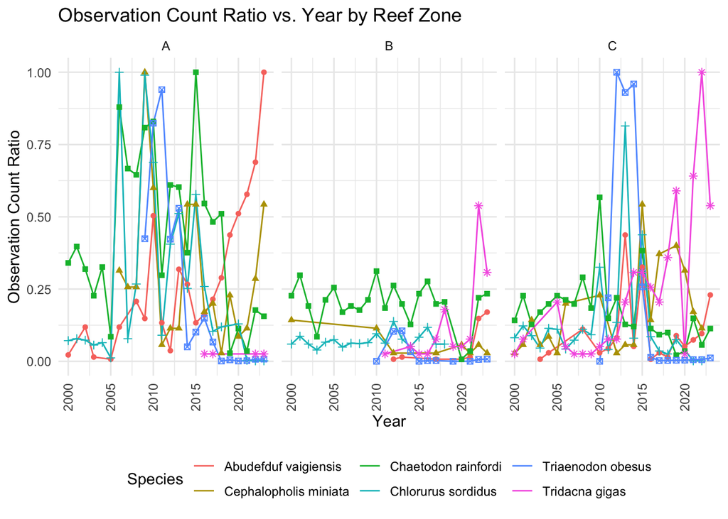

```r
#----Ratio----#

# Calculate the max observation count for each species
species_max <- species_observations_per_zone_year %>%
  group_by(species) %>%
  summarise(max_observation = max(observation_count, na.rm = TRUE))

# Join this with your original data to get the max observation for each row
species_observations_per_zone_year <- species_observations_per_zone_year %>%
  left_join(species_max, by = "species")

# Calculate the ratio
species_observations_per_zone_year <- species_observations_per_zone_year %>%
  mutate(observation_ratio = observation_count / max_observation)


# Plotting the ratio of observation count to max observation count
ggplot(species_observations_per_zone_year, aes(x = year, y = observation_ratio, color = species)) +
  geom_line(aes(group = species)) +
  geom_point(aes(shape = species)) +
  facet_grid(. ~ reef_zone) +
  theme_minimal() +
  labs(title = "Observation Count Ratio vs. Year by Reef Zone",
       x = "Year",
       y = "Observation Count Ratio",
       color = "Species",
       shape = "Species") +
  theme(axis.text.x = element_text(angle = 90, vjust = 0.5, hjust=1),
        legend.position = "bottom") +
  guides(color = guide_legend(override.aes = list(shape = NA)))
```

# Joining Data

```r
# Pivot the data wider by species
wider_data <- species_observations_per_zone_year %>%
  pivot_wider(
    id_cols = c(reef_zone, year),
    names_from = species,
    values_from = observation_count,
    values_fill = list(observation_count = 0)  # Fill missing observations with 0
  ) %>%
  arrange(year)  # Sort by year in ascending order

# View the resulting wide-format tibble
print(wider_data)
```

```
## # A tibble: 72 × 8
##    reef_zone  year `Abudefduf vaigiensis` `Cephalopholis miniata`
##    <chr>     <int>                  <int>                   <int>
##  1 A          2000                      3                       0
##  2 B          2000                      0                       5
##  3 C          2000                      0                       1
##  4 A          2001                      0                       0
##  5 B          2001                      0                       0
##  6 C          2001                      0                       2
##  7 A          2002                     16                       0
##  8 B          2002                      0                       0
##  9 C          2002                      0                       5
## 10 A          2003                      2                       0
## # ℹ 62 more rows
## # ℹ 4 more variables: `Chaetodon rainfordi` <int>, `Chlorurus sordidus` <int>,
## #   `Triaenodon obesus` <int>, `Tridacna gigas` <int>
```

```r
# Assuming YEAR and reef_zone are common in both datasets and properly aligned

#combined_data --> wider_data
#reef_data


# Filter reef_data for years 2000 to 2023
filtered_reef_data <- reef_data %>%
  filter(YEAR >= 2000, YEAR <= 2023)

# Perform the join with wider_data
joined_data <- left_join(wider_data, filtered_reef_data, by = c("year" = "YEAR", "reef_zone"))  %>%  filter(!is.na(SEVERITY_CODE))

# Check the structure of joined_data
print(head(joined_data))
```

```
## # A tibble: 6 × 13
##   reef_zone  year `Abudefduf vaigiensis` `Cephalopholis miniata`
##   <chr>     <dbl>                  <int>                   <int>
## 1 A          2002                     16                       0
## 2 A          2002                     16                       0
## 3 A          2002                     16                       0
## 4 A          2002                     16                       0
## 5 A          2002                     16                       0
## 6 A          2002                     16                       0
## # ℹ 9 more variables: `Chaetodon rainfordi` <int>, `Chlorurus sordidus` <int>,
## #   `Triaenodon obesus` <int>, `Tridacna gigas` <int>, LATITUDE <dbl>,
## #   LONGITUDE <dbl>, SEVERITY_CODE <dbl>, LOCATION <chr>, within_reef <lgl>
```

```r
longer_data <- joined_data %>%
  pivot_longer(
    cols = c("Abudefduf vaigiensis", "Cephalopholis miniata", "Chaetodon rainfordi",
             "Chlorurus sordidus", "Triaenodon obesus", "Tridacna gigas"),
    names_to = "species",
    values_to = "observation_count"
  )
```

# Correlation between Severity Code and Observation Count

## separate model for each species

```r
library(lme4)

unique_species <- unique(longer_data$species)
models <- list()

for (sp in unique_species) {
    species_data <- longer_data[longer_data$species == sp, ]
    models[[sp]] <- lmer(observation_count ~ SEVERITY_CODE + (1 | reef_zone), data = species_data)

    # Print the species name before printing the model summary
    cat("\nModel for Species:", sp, "\n")
    print(summary(models[[sp]]))
}
```

```
##
## Model for Species: Abudefduf vaigiensis
## Linear mixed model fit by REML ['lmerMod']
## Formula: observation_count ~ SEVERITY_CODE + (1 | reef_zone)
##    Data: species_data
##
## REML criterion at convergence: 1702.5
##
## Scaled residuals:
##     Min      1Q  Median      3Q     Max
## -9.6880 -0.1787  0.0161  0.1089  8.8226
##
## Random effects:
##  Groups    Name        Variance Std.Dev.
##  reef_zone (Intercept) 82.07    9.059
##  Residual               2.72    1.649
## Number of obs: 438, groups:  reef_zone, 3
##
## Fixed effects:
##               Estimate Std. Error t value
## (Intercept)    5.46686    5.23250   1.045
## SEVERITY_CODE -0.05199    0.07614  -0.683
##
## Correlation of Fixed Effects:
##             (Intr)
## SEVERITY_CO -0.025
##
## Model for Species: Cephalopholis miniata
## Linear mixed model fit by REML ['lmerMod']
## Formula: observation_count ~ SEVERITY_CODE + (1 | reef_zone)
##    Data: species_data
##
## REML criterion at convergence: 1999.8
##
## Scaled residuals:
##     Min      1Q  Median      3Q     Max
## -2.0907 -0.5186 -0.0182  0.0979  4.1887
##
## Random effects:
##  Groups    Name        Variance Std.Dev.
```

[output cut: 49 more lines]

```
##
## Random effects:
##  Groups    Name        Variance Std.Dev.
##  reef_zone (Intercept)  1251     35.37
##  Residual              10986    104.81
## Number of obs: 438, groups:  reef_zone, 3
##
## Fixed effects:
##               Estimate Std. Error t value
## (Intercept)     74.648     22.649   3.296
## SEVERITY_CODE   -7.030      4.827  -1.456
##
## Correlation of Fixed Effects:
##             (Intr)
## SEVERITY_CO -0.369
```

```
## boundary (singular) fit: see help('isSingular')
```

```
##
## Model for Species: Triaenodon obesus
## Linear mixed model fit by REML ['lmerMod']
## Formula: observation_count ~ SEVERITY_CODE + (1 | reef_zone)
##    Data: species_data
##
## REML criterion at convergence: -1407.8
##
## Scaled residuals:
##     Min      1Q  Median      3Q     Max
## -0.3643 -0.1363 -0.0223  0.0917 20.6993
##
## Random effects:
##  Groups    Name        Variance Std.Dev.
##  reef_zone (Intercept) 0.000000 0.00000
##  Residual              0.002254 0.04748
## Number of obs: 438, groups:  reef_zone, 3
##
## Fixed effects:
##                Estimate Std. Error t value
## (Intercept)    0.011883   0.004357   2.727
## SEVERITY_CODE -0.005411   0.002097  -2.581
##
## Correlation of Fixed Effects:
##             (Intr)
## SEVERITY_CO -0.854
## optimizer (nloptwrap) convergence code: 0 (OK)
## boundary (singular) fit: see help('isSingular')
##
##
## Model for Species: Tridacna gigas
## Linear mixed model fit by REML ['lmerMod']
## Formula: observation_count ~ SEVERITY_CODE + (1 | reef_zone)
##    Data: species_data
##
## REML criterion at convergence: 165.1
##
## Scaled residuals:
##     Min      1Q  Median      3Q     Max
## -0.8379 -0.4722 -0.1438  0.2155  6.2441
##
## Random effects:
##  Groups    Name        Variance Std.Dev.
##  reef_zone (Intercept) 0.008205 0.09058
##  Residual              0.082110 0.28655
## Number of obs: 438, groups:  reef_zone, 3
##
## Fixed effects:
##               Estimate Std. Error t value
## (Intercept)    0.18918    0.05875    3.22
## SEVERITY_CODE -0.07546    0.01319   -5.72
##
## Correlation of Fixed Effects:
##             (Intr)
## SEVERITY_CO -0.389
```

### interpretation

Conversely, Triaenodon obesus exhibits a very minimal negative effect (SEVERITY_CODE estimate: -0.005411) with a singular fit in the model, suggesting potential model fitting issues or lack of data variation. Tridacna gigas shows a moderate negative relationship (SEVERITY_CODE estimate: -0.07546) with relatively low variability across reef zones (reef_zone variance: 0.008205). These species-specific findings highlight the complexity of ecological dynamics within coral reef ecosystems. The variability in response to environmental severity underscores the need for nuanced, species-specific analyses in marine biodiversity studies, considering the distinct ecological roles and sensitivities of different species within reef environments.

## Including species as a Fixed Effect

```r
model <- lmer(observation_count ~ SEVERITY_CODE + species + (1 | reef_zone), data = longer_data)

summary(model)
```

```
## Linear mixed model fit by REML ['lmerMod']
## Formula: observation_count ~ SEVERITY_CODE + species + (1 | reef_zone)
##    Data: longer_data
##
## REML criterion at convergence: 27387.8
##
## Scaled residuals:
##     Min      1Q  Median      3Q     Max
## -0.8287 -0.2309 -0.0230  0.1011 11.5040
##
## Random effects:
##  Groups    Name        Variance Std.Dev.
##  reef_zone (Intercept)  107.9   10.39
##  Residual              1981.5   44.51
## Number of obs: 2628, groups:  reef_zone, 3
##
## Fixed effects:
##                              Estimate Std. Error t value
## (Intercept)                    8.1568     6.5287   1.249
## SEVERITY_CODE                 -1.6958     0.8383  -2.023
## speciesCephalopholis miniata  -4.1461     3.0080  -1.378
## speciesChaetodon rainfordi    28.6941     3.0080   9.539
## speciesChlorurus sordidus     60.0685     3.0080  19.970
## speciesTriaenodon obesus      -6.3196     3.0080  -2.101
## speciesTridacna gigas         -6.2603     3.0080  -2.081
##
## Correlation of Fixed Effects:
##             (Intr) SEVERI spcsCm spcsCr spcsCs spcsTo
## SEVERITY_CO -0.222
## spcsCphlphm -0.230  0.000
## spcsChtdnrn -0.230  0.000  0.500
## spcsChlrrss -0.230  0.000  0.500  0.500
## spcsTrndnob -0.230  0.000  0.500  0.500  0.500
## spcsTrdcngg -0.230  0.000  0.500  0.500  0.500  0.500
```

### interpretation

The model, represented by the formula observation_count ~ SEVERITY_CODE + species + (1 | reef_zone), demonstrates a significant overall negative relationship between severity codes and observation counts, as indicated by the SEVERITY_CODE coefficient of -1.6958. This suggests that an increase in severity code, indicative of more severe environmental conditions, generally leads to a decrease in observation counts across all species. The model’s intercept is set at 8.1568, serving as a baseline for observation counts when other variables are held constant.

Species-specific variations are evident in the model, with certain species showing distinct deviations from the baseline observation counts. For example, speciesChaetodon rainfordi exhibits a substantial increase in observation counts (coefficient: 28.6941), indicating a higher number of observations compared to other species under similar environmental conditions. In contrast, speciesCephalopholis miniata shows a negative deviation from the baseline (coefficient: -4.1461), suggesting fewer observations. The random effects for reef_zone reveal a variance of 107.9, pointing to significant differences in observation counts across various reef zones, which highlights the spatial heterogeneity within reef ecosystems. These findings underscore the complex and nuanced responses of different marine species to varying environmental conditions, emphasizing the need for species-specific conservation and management strategies in coral reef ecosystems.

# Visualization

## Effect of Severity Code on Observation Count for Each Species:

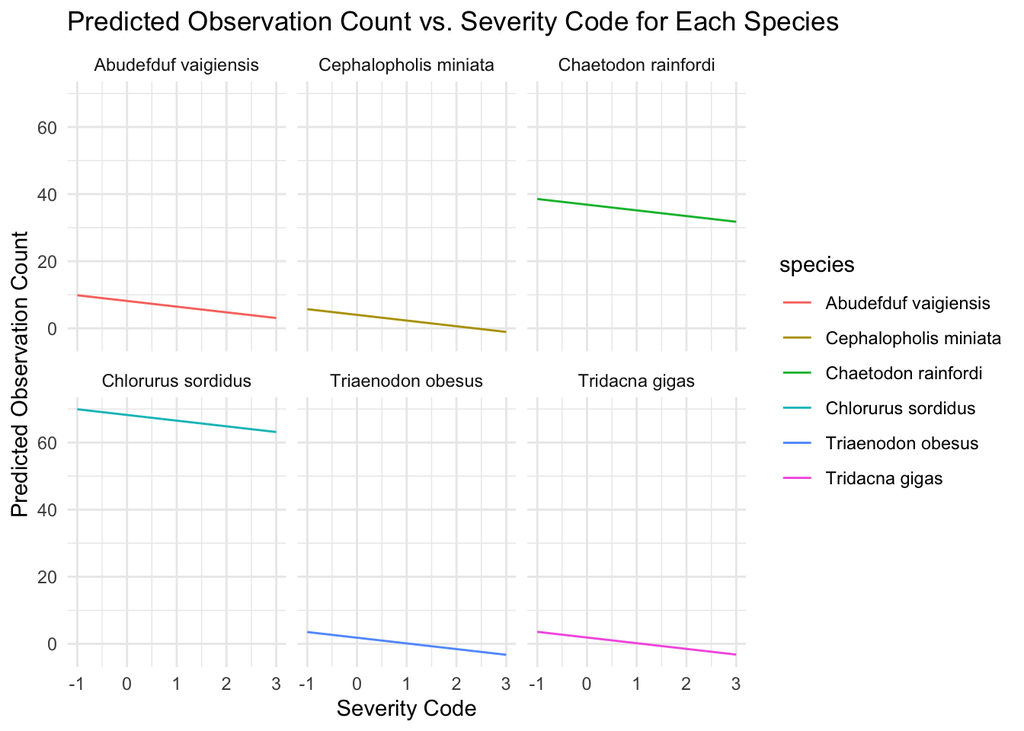

```r
library(ggplot2)
library(lme4)
library(dplyr)

# Fit the model (if not already done)
model <- lmer(observation_count ~ SEVERITY_CODE + species + (1 | reef_zone), data = longer_data)

# Create a new data frame for predictions
new_data <- expand.grid(SEVERITY_CODE = seq(min(longer_data$SEVERITY_CODE), max(longer_data$SEVERITY_CODE), length.out = 100),
                        species = unique(longer_data$species),
                        reef_zone = unique(longer_data$reef_zone))

# Predict observation counts
new_data$predicted_count <- predict(model, newdata = new_data, re.form = NA)

# Plotting
ggplot(new_data, aes(x = SEVERITY_CODE, y = predicted_count, color = species)) +
  geom_line() +
  facet_wrap(~species) +
  labs(title = "Predicted Observation Count vs. Severity Code for Each Species",
       x = "Severity Code",
       y = "Predicted Observation Count") +
  theme_minimal()
```

## Results

The analysis revealed varied relationships between observation counts and severity codes across different species, indicating species-specific responses to environmental changes. Significant differences in observation counts were observed across various reef zones, highlighting spatial heterogeneity within the reef ecosystem. Maps generated for different decades showed the distribution of severity codes, providing a visual representation of coral bleaching impact over time.

## Discussion

The findings of this project illustrate the intricate interplay between environmental severity and marine biodiversity. The differential impact on various species underscores the complexity of coral reef ecosystems and the need for tailored conservation approaches. The spatial analysis across different reef zones emphasizes the importance of considering geographical variability in reef health. Overall, this study contributes valuable insights into the resilience and vulnerability of coral reefs, informing future conservation efforts.

# More Visuals

## Time Series

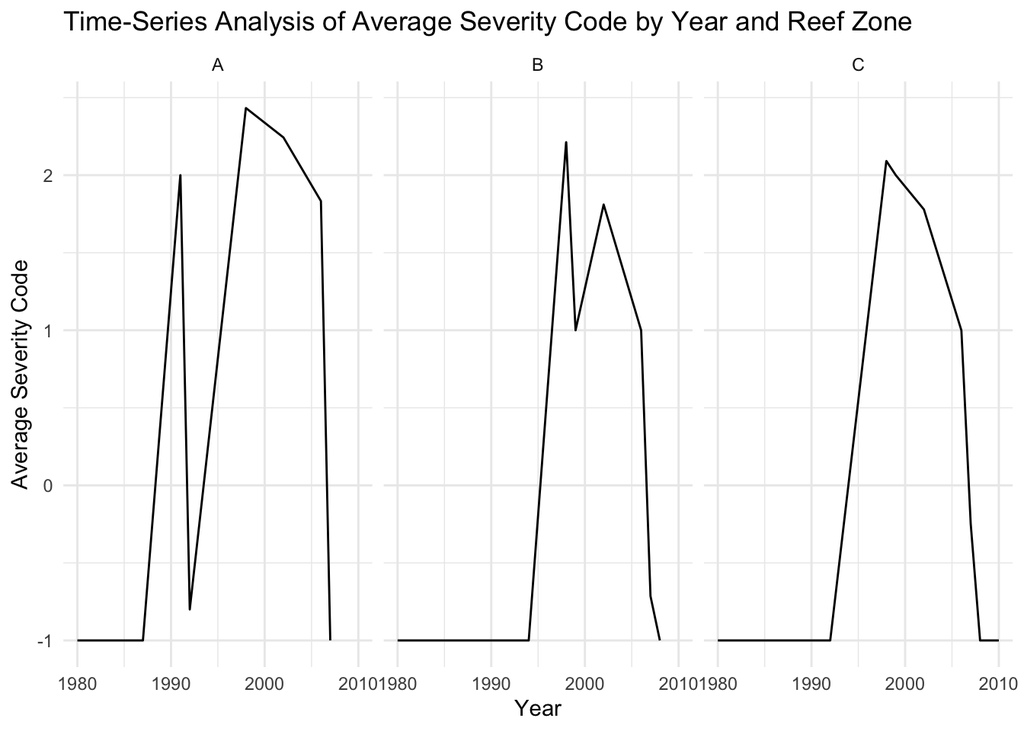

```r
# Time-Series Analysis of Observation Count
ggplot(severity_code_by_year_zone, aes(x = YEAR, y = avg_severity)) +
  geom_line() +
  facet_wrap(~reef_zone) +
  labs(title = "Time-Series Analysis of Average Severity Code by Year and Reef Zone",
       x = "Year", y = "Average Severity Code") +
  theme_minimal()
```

## Heatmaps

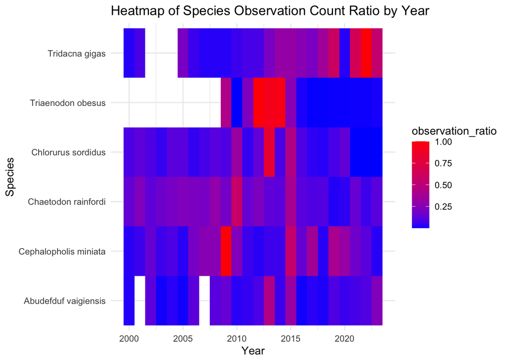

```r
# Assuming the observation_ratio column already exists in species_observations_per_zone_year
ggplot(species_observations_per_zone_year, aes(x = year, y = species, fill = observation_ratio)) +
  geom_tile() +
  scale_fill_gradient(low = "blue", high = "red") +
  labs(title = "Heatmap of Species Observation Count Ratio by Year",
       x = "Year", y = "Species") +
  theme_minimal()
```

## Interactive Dashboards with Shiny

```r
library(shiny)

ui <- fluidPage(
  titlePanel("Coral Reef Analysis Dashboard"),
  sidebarLayout(
    sidebarPanel(
      selectInput("species", "Choose a Species:", choices = unique(species_observations_per_zone_year$species)),
      sliderInput("yearRange", "Select Year Range:",
                  min = min(species_observations_per_zone_year$year),
                  max = max(species_observations_per_zone_year$year),
                  value = c(min(species_observations_per_zone_year$year), max(species_observations_per_zone_year$year)))
    ),
    mainPanel(plotOutput("plot"))
  )
)

server <- function(input, output) {
  output$plot <- renderPlot({
    filtered_data <- species_observations_per_zone_year %>%
      filter(species == input$species, year >= input$yearRange[1], year <= input$yearRange[2])
    ggplot(filtered_data, aes(x = year, y = observation_count)) +
      geom_line() +
      labs(title = paste("Observations of", input$species),
           x = "Year", y = "Observation Count")
  })
}

shinyApp(ui = ui, server = server)
```

[output not shown]

Shiny applications not supported in static R Markdown documents

## Biodiversity Indices

```r
# Calculate Shannon Diversity Index
shannon_diversity <- species_observations_per_zone_year %>%
  group_by(reef_zone, year) %>%
  summarise(diversity = -sum((observation_count / sum(observation_count)) * log(observation_count / sum(observation_count))))
```

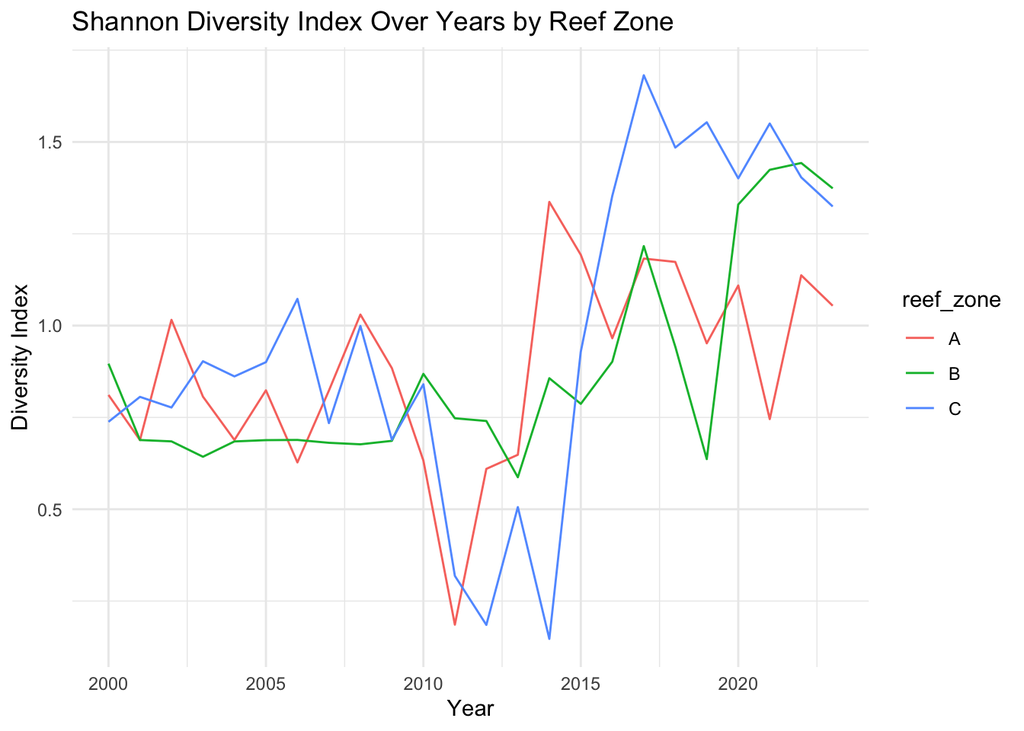

```r
# Plotting Shannon Diversity Index
ggplot(shannon_diversity, aes(x = year, y = diversity, color = reef_zone)) +
  geom_line() +
  labs(title = "Shannon Diversity Index Over Years by Reef Zone",
       x = "Year", y = "Diversity Index") +
  theme_minimal()
```

## Comparative Bar Charts

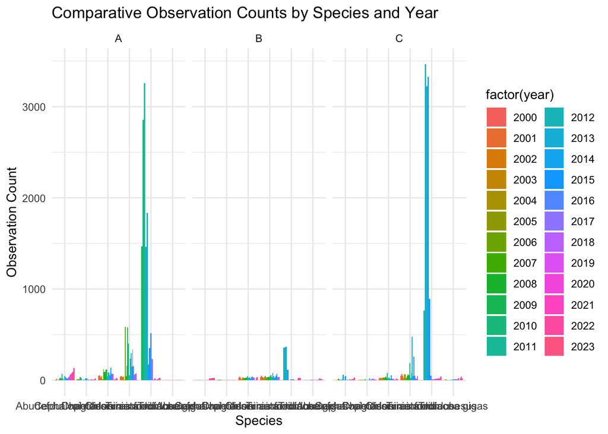

```r
# Comparative Bar Charts
ggplot(species_observations_per_zone_year, aes(x = species, y = observation_count, fill = factor(year))) +
  geom_bar(stat = "identity", position = "dodge") +
  facet_wrap(~reef_zone) +
  labs(title = "Comparative Observation Counts by Species and Year",
       x = "Species", y = "Observation Count") +
  theme_minimal()
```

## Multivariate Analysis (PCA)

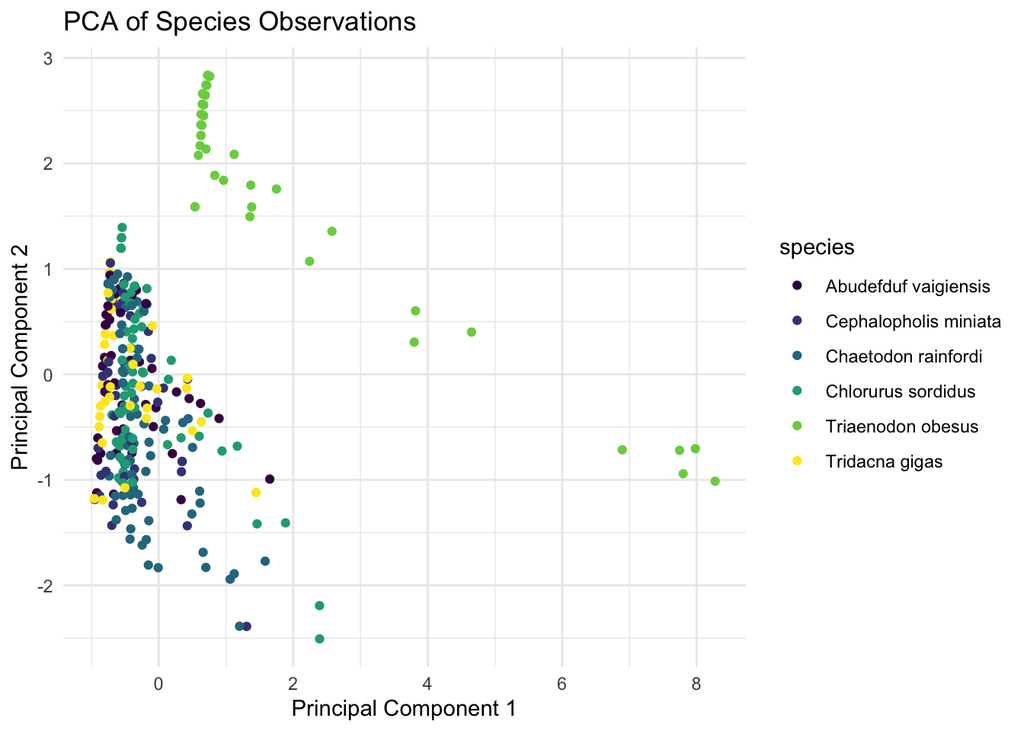

```r
# Assuming species_observations_per_zone_year has numeric variables that we can perform PCA on
# If your data has non-numeric columns, select only numeric ones for PCA

# Conduct PCA
pca_result <- prcomp(species_observations_per_zone_year[, sapply(species_observations_per_zone_year, is.numeric)], center = TRUE, scale. = TRUE)

# Extract PCA scores
pca_scores <- as.data.frame(pca_result$x)

# Add species information back to the PCA scores for coloring
# Make sure that the row order of species_observations_per_zone_year hasn't changed since the PCA was done
pca_scores$species <- species_observations_per_zone_year$species

# Plotting PCA results using ggplot2
ggplot(pca_scores, aes(x = PC1, y = PC2, color = species)) +
  geom_point() +
  labs(title = "PCA of Species Observations",
       x = "Principal Component 1",
       y = "Principal Component 2") +
  theme_minimal() +
  scale_color_viridis_d()
```

## Interpretation of PCA

In this analysis, PC1 and PC2 together form a plane where species are plotted, revealing clustering and potential outliers. PC1 appears to be influenced heavily by the maximum observation counts, suggesting that species with higher overall observations are spread along this axis. PC2 is most impacted by the observation ratio, indicating that this component captures the relative frequency of observations per species. The clusters observed may represent groups of species with similar observation profiles, possibly linked to their ecological characteristics or response to environmental pressures. Outliers could signify species with unique or extreme observation records. The dispersion of points across the two principal components underscores the multifaceted nature of species distribution and abundance, reflecting the complexity of ecological interactions within the coral reef ecosystem. This PCA thus provides a foundational understanding of the data structure, guiding further, more nuanced analyses.